# Check-in 10

Author

Shubhu Shahade

Published

Due November 06, 2023

Remember, you must submit *both* your .Rmd and the compiled .html in order to receive full credit! In addition, to receive full credit, your code output and plots must be correctly formatted.

## Part 1. Training and Test Error (10 points)

Use the following code to generate data:

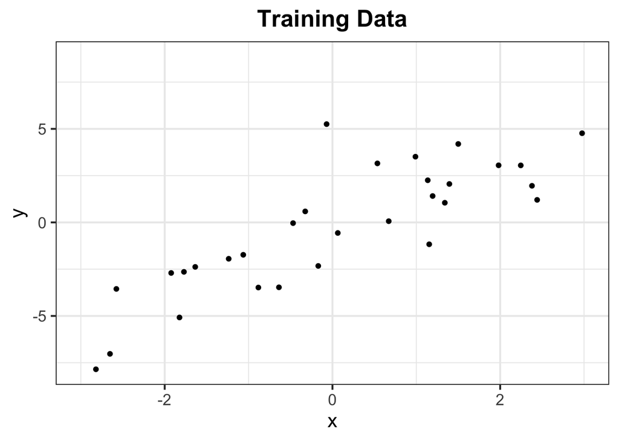

```r
library(ggplot2)
# generate data
set.seed(302)
n <- 30
x <- sort(runif(n, -3, 3))
y <- 2*x + 2*rnorm(n)
x_test <- sort(runif(n, -3, 3))
y_test <- 2*x_test + 2*rnorm(n)
df_train <- data.frame("x" = x, "y" = y)
df_test <- data.frame("x" = x_test, "y" = y_test)

# store a theme
my_theme <- theme_bw(base_size = 16) +
  theme(plot.title = element_text(hjust = 0.5, face = "bold"),
        plot.subtitle = element_text(hjust = 0.5))

# generate plots
g_train <- ggplot(df_train, aes(x = x, y = y)) + geom_point() +
  xlim(-3, 3) + ylim(min(y, y_test), max(y, y_test)) +
  labs(title = "Training Data") + my_theme
g_test <- ggplot(df_test, aes(x = x, y = y)) + geom_point() +
  xlim(-3, 3) + ylim(min(y, y_test), max(y, y_test)) +
  labs(title = "Test Data") + my_theme
g_train
```

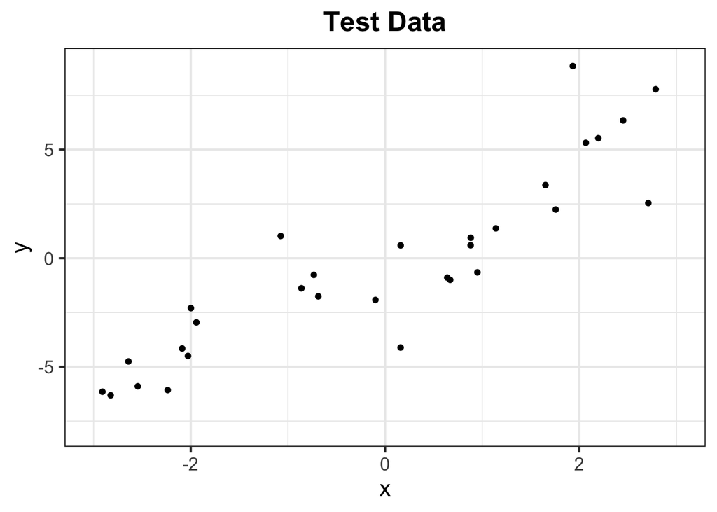

```r
g_test
```

**1a.** For $k = 1$ and $k = 5$, fit a degree-k polynomial linear regression model with `y` as the response and `x` as the explanatory variable(s). (*Hint: Use* `poly()`*, as in the lecture slides.*)

```r
# Function to fit a polynomial regression model and calculate errors
fit_and_evaluate <- function(k, df_train, df_test) {
  # Fit polynomial regression model
  model <- lm(y ~ poly(x, k), data = df_train)

  # Predict on training set
  y_train_pred <- predict(model, newdata = df_train)

  # Calculate training error
  train_error <- mean((df_train$y - y_train_pred)^2)

  # Predict on test set
  #y_test_pred <- predict(model, newdata = df_test)
  y_test_pred <- predict(model, newdata = data.frame("x" = x_test))

  # Calculate test error
  test_error <- mean((df_test$y - y_test_pred)^2)

  return(list("model" = model, "train_error" = train_error, "test_error" = test_error, "Prediction" = y_test_pred))
}

# Fit models for k = 1 and k = 5
model_k1 <- fit_and_evaluate(1, df_train, df_test)
model_k5 <- fit_and_evaluate(5, df_train, df_test)
```

**1b.** For each model from (a), record the training error. Then predict `y_test` using `x_test` and also record the test error.

```r
cat("Model with k = 1:\n")
```

```
Model with k = 1:
```

```r
cat("Training Error: ", model_k1$train_error, "\n")
```

```
Training Error:  3.309081
```

```r
cat("Test Error: ", model_k1$test_error, "\n\n")
```

```
Test Error:  3.865873
```

```r
cat("Prediction: ", model_k1$Prediction, "\n\n")
```

[output not shown]

```r
cat("Model with k = 5:\n")
```

```
Model with k = 5:
```

```r
cat("Training Error: ", model_k5$train_error, "\n")
```

```
Training Error:  2.664344
```

```r
cat("Test Error: ", model_k5$test_error, "\n\n")
```

```
Test Error:  6.109969
```

```r
cat("Prediction: ", model_k5$Prediction, "\n\n")
```

```
Prediction:  -8.212983 -7.370662 -5.933766 -5.353669 -4.076377 -3.686342 -3.556976 -3.497458 -3.39203 -2.121073 -1.728858 -1.465396 -1.365409 0.05192784 0.6833117 0.6848933 1.648773 1.695225 1.966528 1.967768 2.033614 2.157652 2.127896 2.082419 2.011416 1.984058 2.002635 2.269302 3.059824 3.433653
```

**1c.** If you were going to choose a model based on training error, which would you choose? Plot the data, colored by split. Add a line to the plot representing your selection for model fit. Add a subtitle to this plot with the (rounded!) test error. (*Hint: See Lecture Slides for example code.*)

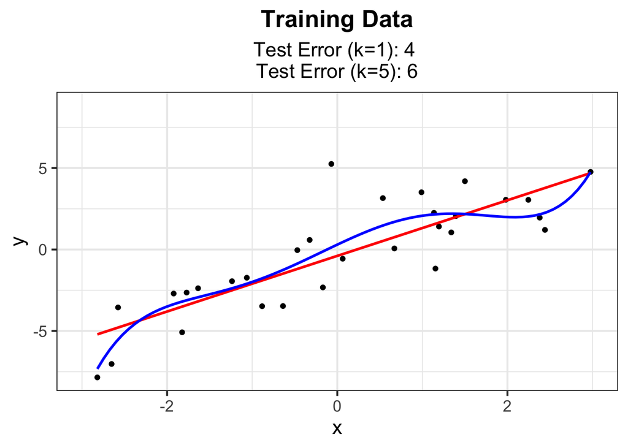

```r
# Plot the data with model fits based on training error
g_train + geom_smooth(method = "lm", formula = y ~ poly(x, 1), color = "red", se = FALSE) +
  geom_smooth(method = "lm", formula = y ~ poly(x, 5), color = "blue", se = FALSE) +
  labs(subtitle = paste("Test Error (k=1):", round(model_k1$test_error), "\nTest Error (k=5):", round(model_k5$test_error)))
```

I’d choose the model with k = 5 since it’s training error is lower when compared to k = 1.

**1d.** If you were going to choose a model based on test error, which would you choose? Plot the data, colored by split. Add a line to the plot representing your selection for model fit. Add a subtitle to this plot with the (rounded!) test error.

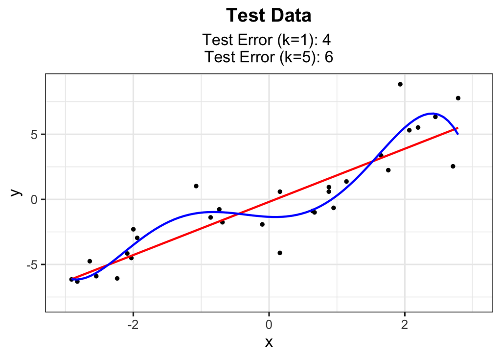

```r
# Plot the data with model fits based on test error
g_test + geom_smooth(method = "lm", formula = y ~ poly(x, 1), color = "red", se = FALSE) +
  geom_smooth(method = "lm", formula = y ~ poly(x, 5), color = "blue", se = FALSE) +
  labs(subtitle = paste("Test Error (k=1):", round(model_k1$test_error), "\nTest Error (k=5):", round(model_k5$test_error)))
```

I’d choose the model with k = 1 since it’s testing error is less than the model with k = 5.

**1e.** What do you notice about the shape of the curves from part (d) and (e)? Which model do you think has lower bias? Lower variance? Why?

In general, a model with lower complexity, such as a lower-degree polynomial, tends to have lower variance and higher bias. On the other hand, a model with higher complexity, such as a higher-degree polynomial, tends to have higher variance and lower bias. The model with k = 1 has lower variance and higher bias. The model with k = 5 has higher variance and lower bias.